# Use FINEMAPR to use FINEMAP, Caviar, and Paintor

Questions: Zscore vs. Pvalue in eQTLGen data

FINEMAP

http://www.christianbenner.com/ https://www.ncbi.nlm.nih.gov/pmc/articles/PMC4495769/

Instructions: https://variani.github.io/finemapr/vignettes/finemapr.html

If using straight FINEMAP, need to include inputs: Master file Z file - minor allele frequencies, beta, and se in z-file LD file BGEN, BGI, SAMPLE, and INCL file

https://github.com/topics/finemap https://github.com/variani/finemapr and https://variani.github.io/finemapr/vignettes/finemapr.html https://github.com/slwest/finemap-scripts

Google search: FINEMAP https://github.com/Ensembl/Finemap https://github.com/jinghuazhao/FM-pipeline https://github.com/manning-lab/fineMap https://github.com/chr1swallace/finemap-psa https://github.com/opentargets/genetics-finemapping https://omictools.com/finemap-tool https://github.com/JoniColeman/gwas_scripts/blob/master/README.md

1000 Genomes https://www.google.com/search?q=background+finemap&oq=background+finemap&aqs=chrome..69i57.1595j0j1&sourceid=chrome&ie=UTF-8 https://www.semanticscholar.org/paper/FINEMAP%3A-efficient-variable-selection-using-summary-Benner-Spencer/08f23c6b03aa51eb83948b750162b63810f838cc https://www.google.com/search?q=1000+genomes+plink+files&oq=1000+genomes+&aqs=chrome.4.69i57j0l5.4991j0j1&sourceid=chrome&ie=UTF-8 https://www.google.com/search?q=1000+genomes+background+score+regression&oq=1000+genomes+background+score+regression&aqs=chrome..69i57.3654j0j1&sourceid=chrome&ie=UTF-8 http://www.internationalgenome.org/data/

git clone https://github.com/gkichaev/PAINTOR_V3.0 git clone https://github.com/fhormoz/caviar git clone https://github.com/variani/finemapr

http://genetics.cs.ucla.edu/caviar/caviar_manual.pdf http://zarlab.cs.ucla.edu/tag/ecaviar/

```r
# Load finemapr
library(devtools)
devtools::load_all("/Users/kathryntsai/Documents/GitHub/finemapr")
```

```
Loading finemapr
replacing previous import ‘Matrix::head’ by ‘utils::head’ when loading ‘finemapr’Adding files missing in collate: abf.R, cojo.R, utils.R
```

```r
#devtools::install_github("variani/finemapr")
library(magrittr)
library(dplyr)
library(ggplot2)
library(knitr)
library(ggthemes)
theme_set(theme_stata())
```

[output not shown]

```r
file1_z <- system.file("extdata/region1.z", package = "finemapr")
file1_ld <- system.file("extdata/region1.ld", package = "finemapr")
z1 <- read_zscore(file1_z)
devtools::load_all("/Users/kathryntsai/Documents/GitHub/finemapr_variani/finemapr/R/finemap.R")
```

```r
chr1_cis <- franke_cis_data[which(GeneChr==1),]
chr1_cis_split <- split(chr1_cis, chr1_cis$GeneSymbol)
ACBD6 <- chr1_cis_split[[11]] # ACBD6
new <- ACBD6[, c("SNP", "Zscore")]
colnames(new) <- c("snp", "zscore")
fwrite(new, "abcd6_z.z", sep="\t", col.names=F)
z1 <- read_zscore("/Users/kathryntsai/OneDrive\ -\ Villanova\ University/College/2018-2019/Summer\ 2019/TFs_eQTLs_Research/RProjects/Project2/finemapping/abcd6_z.z")
# devtools::load_all("/Users/kathryntsai/Documents/GitHub/finemapr_variani/R/finemap.R")
# zz <- read.table("/Users/kathryntsai/OneDrive\ -\ Villanova\ University/College/2018-2019/Summer\ 2019/TFs_eQTLs_Research/RProjects/Project2/finemapping/abcd6_ld.ld", sep="\t", row.names = 1, header=T)
# fwrite(zz, "abcd6_ldlink.ld", sep="\t", row.names=F, col.names=F)
#ld1 <- read_ld("/Users/kathryntsai/OneDrive\ -\ Villanova\ University/College/2018-2019/Summer\ 2019/TFs_eQTLs_Research/RProjects/Project2/finemapping/abcd6_ldlink.ld")
```

```r
ldin <- glue_collapse(ACBD6$SNP, sep="\\n")
sysin <- noquote(gsub("\\n", "\n", gsub('\\\'', "\'", paste('curl -k -H "Content-Type: application/json" -X POST -d \'{', '"snps"', ": \"", ldin, '", "pop": "CEU","r2_d": "r2"}\'', " 'https://ldlink.nci.nih.gov/LDlinkRest/ldmatrix?&token=bc2543d7f1e5' > '/Users/kathryntsai/OneDrive\ -\ Villanova\ University/College/2018-2019/Summer\ 2019/TFs_eQTLs_Research/RProjects/Project2/finemapping/abcd6_ld.ld'", sep=""), str, fixed=T), str, fixed=T))
# doesn't work but idk why --> just use manual
z <- system(sysin)
```

[output not shown]

```r
devtools::load_all("/Users/kathryntsai/Documents/GitHub/finemapr")
```

```r
z1 <- z1[match(row.names(ld1), z1$snp),]
# cuts out 4 snps
ld1 <- ld1[z1$snp %in% rownames(ld1), z1$snp %in% colnames(ld1)] # ensure matrix is square
z1 <- z1[match(row.names(ld1), z1$snp),]
# cuts out rs113028155
ld1 <- ld1[!is.na(round(diag(ld1), 4)),!is.na(round(diag(ld1), 4))] # ensure diagonal exists for caviar
z1 <- z1[match(row.names(ld1), z1$snp),]
# cuts out rs78111936, rs187483246, rs2331743
n1 <- nrow(z1)
```

```r
z1 %>% arrange(-abs(as.numeric(zscore))) %>% head(5) %>% kable(digits = 1)
```

[output not shown]

[figure not shown]

```r
ggplot(z1, aes(zscore)) + geom_histogram(fill='red', color='blue')
```

```
The `printer` argument is deprecated as of rlang 0.3.0.
```

[figure not shown]

```r
mutate(z1, pval = pchisq(zscore^2, df = 1, lower.tail = FALSE)) %>%
  ggplot(aes(pval)) + geom_histogram(fill='red', color='blue')
```

brew install zstd It doesn’t seem to be taking finemap arguments

[figure not shown]

./CAVIAR -z /Users/kathryntsai/OneDrive - Villanova University/College/2018-2019/Summer 2019/TFs_eQTLs_Research/RProjects/Project2/finemapping/Zscore_file_ACBD6.Z -l /Users/kathryntsai/OneDrive - Villanova University/College/2018-2019/Summer 2019/TFs_eQTLs_Research/RProjects/Project2/finemapping/ld_matrix_ACBD6.ld -c 5 -o /Users/kathryntsai/OneDrive - Villanova University/College/2018-2019/Summer 2019/TFs_eQTLs_Research/RProjects/Project2/finemapping/max_casual5 -f 1 -r 0.95

./CAVIAR -o acbd6_folder -l /Users/kathryntsai/OneDrive - Villanova University/College/2018-2019/Summer 2019/TFs_eQTLs_Research/RProjects/Project2/finemapping/acbd6_ld.ld -z /Users/kathryntsai/OneDrive - Villanova University/College/2018-2019/Summer 2019/TFs_eQTLs_Research/RProjects/Project2/finemapping/acbd6_z.txt -c 2 -f 1 -r 0.95

```r
options(finemapr_caviar = "/Users/kathryntsai/Documents/GitHub/caviar/CAVIAR-C++/CAVIAR")
out_caviar <- run_caviar(z1, ld1, args = "-c 3")
```

[output not shown]

[output not shown]

[output cut: 22920 more lines]

[output not shown]

```
Total Likelihood= 2.690223e+02 SNP=410

37 3.333332e-01
108 4.940131e-01
240 6.052012e-01
24 6.957894e-01
22 7.771650e-01
34 8.576371e-01
219 9.067478e-01
210 9.229912e-01
104 9.357572e-01
200 9.464813e-01
60 9.567189e-01
```

```r
print(out_caviar)
```

```
 - command: /Users/kathryntsai/Documents/GitHub/caviar/CAVIAR-C++/CAVIAR -c 3 -z region.z -l region.ld -o log
 - tables of results: `snp`
 - snp:
```

| rank | snp | snp_prob_set | snp_prob |
| --- | --- | --- | --- |
| 1 | rs75468761 | 3.33333e-01 | 9.99999e-01 |
| 2 | rs114517401 | 1.60680e-01 | 4.82040e-01 |
| 3 | rs77389071 | 1.11188e-01 | 3.33564e-01 |
| 4 | rs7536561 | 9.05882e-02 | 2.71765e-01 |
| 5 | rs3845397 | 8.13756e-02 | 2.44127e-01 |
| 6 | rs716760 | 8.04721e-02 | 2.41416e-01 |
| 7 | rs76937829 | 4.91107e-02 | 1.47332e-01 |
| 8 | rs4076403 | 1.62434e-02 | 4.87301e-02 |
| 9 | rs10753208 | 1.27660e-02 | 3.82980e-02 |
| 10 | rs4578179 | 1.07242e-02 | 3.21725e-02 |

[output cut: 400 more lines]

```
 - 95%-causal set (ordered): rs75468761, rs114517401, rs77389071, rs7536561, rs3845397, rs716760, rs76937829, rs4076403, rs10753208, rs4578179, rs2296378
```

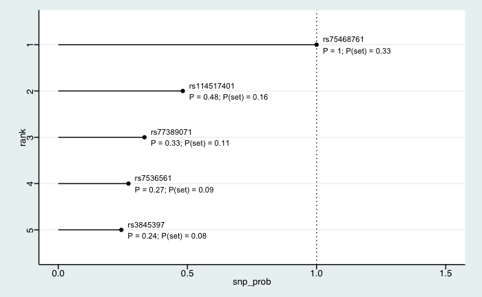

```r
plot(out_caviar, label_size = 3)
```

```r
options(finemapr_paintor = "/Users/kathryntsai/Documents/GitHub/PAINTOR_V2.1/PAINTOR")
devtools::load_all("/Users/kathryntsai/Documents/GitHub/finemapr/R/paintor.R")
```